[figure not shown]

Analyse du stock et des ventes du site  
Bottleneck

# 🎯 Objectif du projet — Bottleneck 🍷

Ce notebook a pour objectif de **centraliser, nettoyer et analyser les données de ventes et de stocks de l’entreprise Bottleneck**, afin d’en extraire des **insights pertinents pour le comité de direction (CODIR)**.

## 🧩 Contexte

L’entreprise Bottleneck utilise actuellement plusieurs sources de données indépendantes :

- Une **extraction de l’ERP** (références produits, prix, état du stock),
- Une **extraction du site Web** (SKU, quantités vendues, descriptions produits, etc.),
- Une **table de liaison** permettant de relier les références entre les deux systèmes.

Cependant, des divergences existent entre ces fichiers (erreurs de saisie, types de données incohérents, références non correspondantes), rendant les analyses complexes.

## 📈 Objectifs principaux

Le travail se décompose en deux phases :

### Phase 1 — Agrégation et fiabilisation des données

- Rapprocher les extractions **ERP** et **Web** via la table de liaison,
- Identifier les **erreurs et incohérences** dans les données (saisie, calcul, jointure, etc.),
- Proposer des **solutions d’amélioration** pour fiabiliser les données en amont.

### Phase 2 — Analyses statistiques et interprétation

- Calcul du **chiffre d’affaires total et par produit**,
- Détection et visualisation des **valeurs aberrantes** (Z-Score, écart interquartile, boxplot),
- Étude du **taux de marge**, de la **rotation des stocks** et des **mois de couverture**,
- Analyse des **corrélations** entre les variables quantitatives : prix, prix d’achat, stock, ventes, marge, etc.

## 🧠 Finalité

Les résultats présentés dans ce notebook serviront :

- À alimenter la **prise de décision du CODIR**,
- À préparer la **future refonte du système de data visualisation**,
- Et à définir une **base de données conforme et cohérente**, respectant les exigences **RGPD**.

> 💡 *L’ensemble de cette étude a été menée dans une optique de clarté, de rigueur et de reproductibilité, afin d’offrir à Bottleneck une vision fiable de ses performances commerciales.*

## 📘 Sommaire

- Étape 1 - Importation des librairies et chargement des fichiers
  - 📘 1.1 - Importation des librairies
  - 📗 1.2 - Chargement des fichiers
- Étape 2 - Analyse exploratoire des fichiers
  - 📊 2.1 - Analyse exploratoire du fichier erp.xlsx
  - 📊 2.1.1 - Analyse exploratoire de chaque variable du fichier erp.xlsx
  - 🔹 2.1.1.1 - Analyse de la variable PRIX
  - 🔹 2.1.1.2 - Analyse de la variable STOCK
  - 🔹 2.1.1.3 - Analyse de la variable ONSALE_WEB
  - 🔹 2.1.1.4 - Analyse de la variable prix d'achat
  - 📊 2.2 - Analyse exploratoire du fichier web.xlsx
  - 📊 2.3 - Analyse exploratoire du fichier liaison.xlsx
- Étape 3 - Jonction des fichiers
  - 🔸 3.1 - Jonction du fichier df_erp et df_liaison
  - 🔸 3.2 - Jonction du fichier df_merge et df_web
- Étape 4 - Analyse univariée des prix
  - 📈 4.1 - Exploration par la visualisation de données
  - 📉 4.2 - Exploration par l'utilisation de méthodes statistiques
  - 🔹 4.2.1 - Identification par le Z-index
  - 🔹 4.2.2 - Identification par l'intervalle interquartile
- Étape 5 - Analyse univariée du CA, des quantités vendues, des stocks et de la marge ainsi qu'une analyse multivariée
  - 💰 5.1 - Analyse des ventes en CA
  - 📦 5.2 - Analyse des ventes en quantité
  - 📊 5.3 - Analyse des stocks
  - 📈 5.4 - Analyse du taux de marge
  - 🔗 5.5 - Corrélations entre stock, sales et price
  - 🧾 5.6 - Mise à disposition du fichier Excel final

## Étape 1 - Importation des librairies et chargement des fichiers

### 1.1 - Importation des librairies

```python
#Importation de la librairie Pandas
from IPython.display import display, HTML
import pandas as pd
import numpy as np
import matplotlib.pyplot as plt
import plotly.express as px
import seaborn as sns
import warnings
warnings.filterwarnings("ignore", category=UserWarning, module="openpyxl")

print("Tout est installé et prêt 🎉")
```

```
Tout est installé et prêt 🎉
```

```python
#Importation de la librairie plotly express (attention peut bug)
import plotly.express as px
```

```python
# Affichage de toutes les colonnes du dataframe
pd.set_option('display.max_columns', None)
```

**Réponse :**  
pd.set_option( 'display.max_columns', None)

✅ Toutes les colonnes du DataFrame seront désormais affichées.

### 1.2 - Chargements des fichiers

```python
#Importation du fichier web.xlsx
df_web = pd.read_excel("data/web.xlsx")

#Importation du fichier erp.xlsx
df_erp = pd.read_excel("data/erp.xlsx")

#Importation du fichier liaison.xlsx
df_liaison = pd.read_excel("data/liaison.xlsx")
```

**Résultat :** 🔥 Importation terminée :  
les fichiers **web.xlsx**, **erp.xlsx** et **liaison.xlsx** sont chargés avec succès !

## Etape 2 - Analyse exploratoire des fichiers

### 2.1 - Analyse exploratoire du fichier erp.xlsx

```python
#Afficher les dimensions du dataset
rows, cols = df_erp.shape
display(HTML(f"""
<p style='font-family: Segoe UI, Arial; font-size:18px; color:#e0e0e0;'>
Le tableau comporte <span style='color:#ffcc00; font-weight:bold;'>{rows:,}</span> observation(s) ou article(s)<br>
Le tableau comporte <span style='color:#ffcc00; font-weight:bold;'>{cols}</span> colonne(s)
</p>
"""))
```

Le tableau comporte 825 observation(s) ou article(s)  
Le tableau comporte 6 colonne(s)

```python
#Consulter le nombre de colonnes
print("Nombre de colonnes :", df_erp.shape[1])

#La nature des données dans chacune des colonnes
print("\n\033[96mTypes de données :\033[0m")
print(df_erp.dtypes)

#Le nombre de valeurs présentes dans chacune des colonnes
print("\n\033[96mValeurs non nulles par colonne :\033[0m")
print(df_erp.count())
```

```
Nombre de colonnes : 6

Types de données :
product_id          int64
onsale_web          int64
price             float64
stock_quantity      int64
stock_status       object
purchase_price    float64
dtype: object

Valeurs non nulles par colonne :
product_id        825
onsale_web        825
price             825
stock_quantity    825
stock_status      825
purchase_price    825
dtype: int64
```

```python
#Afficher les 5 premières lignes de la table
df_erp.head()
```

|  | product_id | onsale_web | price | stock_quantity | stock_status | purchase_price |
| --- | --- | --- | --- | --- | --- | --- |
| 0 | 3847 | 1 | 24.2 | 16 | instock | 12.88 |
| 1 | 3849 | 1 | 34.3 | 10 | instock | 17.54 |
| 2 | 3850 | 1 | 20.8 | 0 | outofstock | 10.64 |
| 3 | 4032 | 1 | 14.1 | 26 | instock | 6.92 |
| 4 | 4039 | 1 | 46.0 | 3 | outofstock | 23.77 |

```python
#Vérifier si il y a des lignes en doublon dans la colonne product_id
df_erp["product_id"].duplicated().sum()
```

```
np.int64(0)
```

```python
#Afficher les valeurs distinctes de la colonne stock_status
print("\033[96mValeurs distinctes de stock_status :\033[0m", df_erp["stock_status"].unique())

# Fréquence d'apparition
print("\n\033[96mFréquence de chaque valeur :\033[0m")
print(df_erp["stock_status"].value_counts())

# Relation entre stock_status et stock_quantity
print("\n\033[96mCorrélation entre 'stock_status' et 'stock_quantity' :\033[0m")
pd.crosstab(df_erp["stock_status"], df_erp["stock_quantity"])
```

```
Valeurs distinctes de stock_status : ['instock' 'outofstock']

Fréquence de chaque valeur :
stock_status
instock       733
outofstock     92
Name: count, dtype: int64

Corrélation entre 'stock_status' et 'stock_quantity' :
```

| stock_quantity stock_status | -10 | -1 | 0 | 1 | 2 | 3 | 4 | 5 | 6 | 7 | 8 | 9 | 10 | 11 | 12 | 13 | 14 | 15 | 16 | 17 | 18 | 19 | 20 | 21 | 22 | 23 | 24 | 25 | 26 | … |
| --- | --- | --- | --- | --- | --- | --- | --- | --- | --- | --- | --- | --- | --- | --- | --- | --- | --- | --- | --- | --- | --- | --- | --- | --- | --- | --- | --- | --- | --- | --- |
| instock | 0 | 0 | 1 | 12 | 6 | 17 | 21 | 27 | 21 | 32 | 21 | 17 | 19 | 14 | 29 | 10 | 18 | 19 | 21 | 13 | 16 | 14 | 10 | 14 | 13 | 30 | 21 | 12 | 18 | … |
| outofstock | 1 | 1 | 89 | 0 | 0 | 1 | 0 | 0 | 0 | 0 | 0 | 0 | 0 | 0 | 0 | 0 | 0 | 0 | 0 | 0 | 0 | 0 | 0 | 0 | 0 | 0 | 0 | 0 | 0 | … |

```python
# Création d'une colonne "stock_status_2"
# La valeur de cette deuxième colonne sera fonction de la valeur dans la colonne "stock_quantity"
# Si la valeur de la colonne "stock_quantity" est nulle, renseigner "outofstock" sinon mettre "instock"
# Création de la colonne "stock_status_2"
df_erp["stock_status_2"] = df_erp["stock_quantity"].apply(
    lambda x: "outofstock" if pd.isna(x) or x == 0 else "instock"
)

# Vérification sur quelques lignes
df_erp[["stock_quantity", "stock_status_2"]].head(10)
pd.crosstab(df_erp["stock_status_2"], df_erp["stock_quantity"])
```

| stock_quantity stock_status_2 | -10 | -1 | 0 | 1 | 2 | 3 | 4 | 5 | 6 | 7 | 8 | 9 | 10 | 11 | 12 | 13 | 14 | 15 | 16 | 17 | 18 | 19 | 20 | 21 | 22 | 23 | 24 | 25 | 26 | … |
| --- | --- | --- | --- | --- | --- | --- | --- | --- | --- | --- | --- | --- | --- | --- | --- | --- | --- | --- | --- | --- | --- | --- | --- | --- | --- | --- | --- | --- | --- | --- |
| instock | 1 | 1 | 0 | 12 | 6 | 18 | 21 | 27 | 21 | 32 | 21 | 17 | 19 | 14 | 29 | 10 | 18 | 19 | 21 | 13 | 16 | 14 | 10 | 14 | 13 | 30 | 21 | 12 | 18 | … |
| outofstock | 0 | 0 | 90 | 0 | 0 | 0 | 0 | 0 | 0 | 0 | 0 | 0 | 0 | 0 | 0 | 0 | 0 | 0 | 0 | 0 | 0 | 0 | 0 | 0 | 0 | 0 | 0 | 0 | 0 | … |

```python
# Vérifions que les 2 colonnes sont identiques:
# Les 2 colonnes sont strictement identiques si les valeurs de chaque ligne sont strictement identiques 2 à 2
# La comparaison de 2 colonnes peut se réaliser simplement avec l'instruction ci-dessous:
df_erp["stock_status"] == df_erp["stock_status_2"]

# Le résultat est l'affichage de True ou False pour chacune des lignes du dataset
# C'est un bon début, mais difficile à explo2iter
df_erp[df_erp["stock_status"] != df_erp["stock_status_2"]]
```

|  | product_id | onsale_web | price | stock_quantity | stock_status | purchase_price | stock_status_2 |
| --- | --- | --- | --- | --- | --- | --- | --- |
| 4 | 4039 | 1 | 46.0 | 3 | outofstock | 23.77 | instock |
| 398 | 4885 | 1 | 18.7 | 0 | instock | 9.66 | outofstock |
| 449 | 4973 | 0 | 10.0 | -10 | outofstock | 4.96 | instock |
| 573 | 5700 | 1 | 44.5 | -1 | outofstock | 22.30 | instock |

```python
# Calcul de la somme des valeurs True (1) et False (0)
somme_identiques = (df_erp["stock_status"] == df_erp["stock_status_2"]).sum()

# Affichons le résultat
print(f"Nombre de lignes identiques : {somme_identiques}")
print(f"Nombre total de lignes : {len(df_erp)}")

# Vérifions si les deux colonnes sont strictement identiques
if somme_identiques == len(df_erp):
    print("✅ Les deux colonnes sont strictement identiques.")
else:
    print(f"⚠️ Il y a {len(df_erp) - somme_identiques} différence(s) entre les deux colonnes.")
```

```
Nombre de lignes identiques : 821
Nombre total de lignes : 825
⚠️ Il y a 4 différence(s) entre les deux colonnes.
```

**Résultat :** 821/825 lignes identiques.  
⚠️ 4 différences détectées.

```python
# Identifier les lignes où les valeurs diffèrent
differences = df_erp[df_erp["stock_status"] != df_erp["stock_status_2"]]

# Afficher les lignes en écart
display(differences)
```

|  | product_id | onsale_web | price | stock_quantity | stock_status | purchase_price | stock_status_2 |
| --- | --- | --- | --- | --- | --- | --- | --- |
| 4 | 4039 | 1 | 46.0 | 3 | outofstock | 23.77 | instock |
| 398 | 4885 | 1 | 18.7 | 0 | instock | 9.66 | outofstock |
| 449 | 4973 | 0 | 10.0 | -10 | outofstock | 4.96 | instock |
| 573 | 5700 | 1 | 44.5 | -1 | outofstock | 22.30 | instock |

```python
# Correction des incohérences entre stock_status, stock_status_2 et stock_quantity

# Logique de cohérence :
df_erp.loc[df_erp["stock_quantity"] > 0, ["stock_status", "stock_status_2"]] = "instock"
df_erp.loc[df_erp["stock_quantity"] <= 0, ["stock_status", "stock_status_2"]] = "outofstock"

# Vérification après correction
somme_identiques = (df_erp["stock_status"] == df_erp["stock_status_2"]).sum()
total_lignes = len(df_erp)
ecarts = total_lignes - somme_identiques

print(f"✅ Nombre de lignes identiques : {somme_identiques}")
print(f"📄 Nombre total de lignes : {total_lignes}")
if ecarts == 0:
    print("🟩 Les deux colonnes sont désormais cohérentes avec le stock.")
else:
    print(f"⚠️ {ecarts} différence(s) restante(s).")
```

```
✅ Nombre de lignes identiques : 825
📄 Nombre total de lignes : 825
🟩 Les deux colonnes sont désormais cohérentes avec le stock.
```

**Résultat :** 825/825 lignes identiques.  
✅ Les deux colonnes sont désormais cohérentes.

### 2.1.1 - Analyse exploratoire de chaque variable du fichier erp.xlsx

```python
# Analyse exploratoire de chaque variable du fichier erp.xlsx

# Afficher les types de chaque colonne
print("📊 Types des variables :")
print(df_erp.dtypes)

# Vérifier les valeurs manquantes
print("\n❓ Valeurs manquantes :")
print(df_erp.isna().sum())

# Afficher le nombre de valeurs uniques par colonne
print("\n🔢 Nombre de valeurs uniques :")
print(df_erp.nunique())

# Afficher un résumé statistique pour les variables numériques
print("\n📈 Résumé statistique des variables numériques :")
display(df_erp.describe())
```

```
📊 Types des variables :
product_id          int64
onsale_web          int64
price             float64
stock_quantity      int64
stock_status       object
purchase_price    float64
stock_status_2     object
dtype: object

❓ Valeurs manquantes :
product_id        0
onsale_web        0
price             0
stock_quantity    0
stock_status      0
purchase_price    0
stock_status_2    0
dtype: int64

🔢 Nombre de valeurs uniques :
product_id        825
onsale_web          2
price             383
stock_quantity     84
stock_status        2
purchase_price    660
stock_status_2      2
dtype: int64

📈 Résumé statistique des variables numériques :
```

|  | product_id | onsale_web | price | stock_quantity | purchase_price |
| --- | --- | --- | --- | --- | --- |
| count | 825.000000 | 825.000000 | 825.000000 | 825.000000 | 825.000000 |
| mean | 5162.597576 | 0.867879 | 32.187697 | 21.589091 | 16.940582 |
| std | 902.644635 | 0.338828 | 26.712077 | 21.933807 | 14.561840 |
| min | 3847.000000 | 0.000000 | -20.000000 | -10.000000 | 2.740000 |
| 25% | 4348.000000 | 1.000000 | 14.500000 | 7.000000 | 7.590000 |
| 50% | 4907.000000 | 1.000000 | 24.300000 | 18.000000 | 12.710000 |
| 75% | 5805.000000 | 1.000000 | 42.000000 | 30.000000 | 22.020000 |
| max | 7338.000000 | 1.000000 | 225.000000 | 145.000000 | 137.810000 |

🔍 **Analyse exploratoire du fichier erp.xlsx**

❗ Valeurs manquantes détectées : 0

### 2.1.1.1 - Analyse de la variable PRIX

```python
###############
## LES PRIX  ##
###############

# Vérification des prix: Y a-t-il des prix non renseignés, négatifs ou nuls ?

prix_negatifs = df_erp[df_erp["price"] < 0].copy()
cols = ["product_id", "price", "purchase_price", "stock_quantity", "stock_status", "stock_status_2"]
cols = [c for c in cols if c in prix_negatifs.columns]

print("Produits avec un prix négatif :", len(prix_negatifs))
display(prix_negatifs[cols].sort_values("price").reset_index(drop=True))
```

```
Produits avec un prix négatif : 3
```

|  | product_id | price | purchase_price | stock_quantity | stock_status | stock_status_2 |
| --- | --- | --- | --- | --- | --- | --- |
| 0 | 4233 | -20.0 | 10.33 | 0 | outofstock | outofstock |
| 1 | 6594 | -9.1 | 4.61 | 19 | instock | instock |
| 2 | 5017 | -8.0 | 4.34 | 0 | outofstock | outofstock |

```python
# Afficher le ou les prix non renseignés dans la colonne "price"
print("Nombres d'articles avec un prix non renseigné: {}".format(df_erp["price"].isna().sum()))

# Afficher le prix minimum de la colonne "price"
print("Prix minimum :", df_erp["price"].min())

# Afficher le prix maximum de la colonne "price"
print("Prix maximum :", df_erp["price"].max())

# Afficher les prix inférieurs à 0 (qu'est-ce qu'il faut en faire ?)
print("Prix inférieurs à 0 :", df_erp[df_erp["price"] < 0])
```

```
Nombres d'articles avec un prix non renseigné: 0
Prix minimum : -20.0
Prix maximum : 225.0
Prix inférieurs à 0 :      product_id  onsale_web  price  stock_quantity stock_status  \
151        4233           0  -20.0               0   outofstock
469        5017           0   -8.0               0   outofstock
739        6594           0   -9.1              19      instock

     purchase_price stock_status_2
151           10.33     outofstock
469            4.34     outofstock
739            4.61        instock
```

💰 **Analyse de la variable price**

📊 Aucun prix manquant détecté : 0

🔽 **Prix minimum :** -20.0  
🔼 **Prix maximum :** 225.0

⚠️ **Produits avec un prix négatif :** 3  
(Les valeurs négatives devront être corrigées ou remplacées par 0.)

```python
# Correction des incohérences détectées dans la variable "price"

# Remplacer les NaN (au cas où certains apparaîtraient encore)
df_erp["price"] = df_erp["price"].fillna(0)

# Corriger les prix négatifs
prix_negatifs = (df_erp["price"] < 0).sum()
df_erp.loc[df_erp["price"] < 0, "price"] = 0

# Vérifier après correction
prix_min = df_erp["price"].min()
prix_max = df_erp["price"].max()
prix_manquants = df_erp["price"].isna().sum()

print(f"✅ Prix corrigés avec succès.\nPrix min : {prix_min}\nPrix max : {prix_max}\nPrix manquants : {prix_manquants}")
```

```
✅ Prix corrigés avec succès.
Prix min : 0.0
Prix max : 225.0
Prix manquants : 0
```

**Résultat :**  
✅ Toutes les incohérences sur la variable **price** ont été corrigées.  
Les valeurs manquantes ont été remplacées et les prix négatifs ajustés à **0**.  
📊 Les données sont désormais prêtes pour l’analyse.

### 2.1.1.2 - Analyse de la variable STOCK

```python
#####################
### stock_quantity ###
#####################

# Vérification de la colonne stock_quantity
# Afficher la quantité minimum de la colonne "stock_quantity"
print("Quantité minimum :", df_erp["stock_quantity"].min())

# Afficher la quantité maximum de la colonne "stock_quantity"
print("Quantité maximum :", df_erp["stock_quantity"].max())

# Afficher les stocks inférieurs à 0 (qu'est-ce qu'il faut en faire ?)
stocks_negatifs = df_erp[df_erp["stock_quantity"] < 0]
print("Stocks inférieurs à 0 :")
display(stocks_negatifs)
```

```
Quantité minimum : -10
Quantité maximum : 145
Stocks inférieurs à 0 :
```

|  | product_id | onsale_web | price | stock_quantity | stock_status | purchase_price | stock_status_2 |
| --- | --- | --- | --- | --- | --- | --- | --- |
| 449 | 4973 | 0 | 10.0 | -10 | outofstock | 4.96 | outofstock |
| 573 | 5700 | 1 | 44.5 | -1 | outofstock | 22.30 | outofstock |

📦 **Analyse de la variable stock_quantity**

🔽 **Quantité minimum :** -10  
🔼 **Quantité maximum :** 145

⚠️ **Produits avec un stock négatif :** 2  
(Les valeurs négatives indiquent une erreur de saisie et doivent être corrigées.)

```python
# Correction des incohérences dans la variable "stock_quantity"

# Identifier combien de valeurs négatives il y avait
stocks_negatifs = (df_erp["stock_quantity"] < 0).sum()
print(f"⚠️ Nombre de produits avec stock négatif avant correction : {stocks_negatifs}")

# Corriger les valeurs négatives en les remplaçant par 0
df_erp.loc[df_erp["stock_quantity"] < 0, "stock_quantity"] = 0

# Vérifier après correction
stock_min = df_erp["stock_quantity"].min()
stock_max = df_erp["stock_quantity"].max()
stocks_negatifs_apres = (df_erp["stock_quantity"] < 0).sum()

print("\n✅ Correction effectuée avec succès.")
print(f"Quantité minimale après correction : {stock_min}")
print(f"Quantité maximale : {stock_max}")
print(f"Stocks négatifs restants : {stocks_negatifs_apres}")
```

```
⚠️ Nombre de produits avec stock négatif avant correction : 2

✅ Correction effectuée avec succès.
Quantité minimale après correction : 0
Quantité maximale : 145
Stocks négatifs restants : 0
```

**Résultat :**  
✅ Toutes les valeurs négatives de **stock_quantity** ont été remplacées par **0**.  
📦 Les stocks sont désormais cohérents et prêts pour les opérations de fusion ou d’analyse.

### 2.1.1.3 - Analyse de la variable ONSALE_WEB

```python
#Vérification de la colonne onsale_web et des valeurs qu'elle contient. Que signifient-elles?
print("Valeurs uniques de la colonne 'onsale_web' :", df_erp["onsale_web"].unique())
print("\nFréquence de chaque valeur :\n", df_erp["onsale_web"].value_counts())

# Interprétation :
# 0 signifie que le produit n'est pas en vente sur le site web
# 1 signifie que le produit est en vente en ligne
```

```
Valeurs uniques de la colonne 'onsale_web' : [1 0]

Fréquence de chaque valeur :
 onsale_web
1    716
0    109
Name: count, dtype: int64
```

```python
#Quelles sont les colonnes à conserver selon vous?
# Colonnes pertinentes à conserver pour l’analyse
colonnes_a_conserver = ["product_id", "onsale_web", "price", "purchase_price", "stock_quantity", "stock_status", "stock_status_2"]
df_erp = df_erp[colonnes_a_conserver]

print("Colonnes conservées :", list(df_erp.columns))
```

```
Colonnes conservées : ['product_id', 'onsale_web', 'price', 'purchase_price', 'stock_quantity', 'stock_status', 'stock_status_2']
```

```python
#Supprimer la colonne comportant le libellé "stock_status_2" car elle est redondante
#avec la colonne "stock_status".
# Suppression de la colonne redondante
df_erp = df_erp.drop(columns=["stock_status"], errors="ignore")

# On renomme la colonne corrigée
df_erp = df_erp.rename(columns={"stock_status_2": "stock_status"})

print("✅ Colonne 'stock_status' mise à jour à partir de 'stock_status_2'.")
print("Colonnes finales :", list(df_erp.columns))
```

```
✅ Colonne 'stock_status' mise à jour à partir de 'stock_status_2'.
Colonnes finales : ['product_id', 'onsale_web', 'price', 'purchase_price', 'stock_quantity', 'stock_status']
```

🌐 **Analyse de la variable onsale_web**

Cette variable indique si le produit est disponible à la vente sur le site web :  
**1** ➜ En ligne  
**0** ➜ Non disponible

📊 La majorité des produits sont disponibles en ligne (716 contre 109 hors ligne).

✅ Colonnes conservées : product_id, onsale_web, price, purchase_price, stock_quantity, stock_status  
🧩 La colonne **stock_status_2** a été conservée et renommée en **stock_status** après vérification de la cohérence des données.

### 2.1.1.4 - Analyse de la variable prix d'achat

```python
######################
##   prix d'achat   ##
######################
# Vérification de la colonne purchase_price
print("Nombres d'articles avec un prix d'achat non renseigné :", df_erp["purchase_price"].isna().sum())

# Afficher le prix minimum de la colonne "purchase_price"
print("Prix d'achat minimum :", df_erp["purchase_price"].min())

# Afficher le prix maximum de la colonne "purchase_price"
print("Prix d'achat maximum :", df_erp["purchase_price"].max())
```

```
Nombres d'articles avec un prix d'achat non renseigné : 0
Prix d'achat minimum : 2.74
Prix d'achat maximum : 137.81
```

💰 **Analyse de la variable purchase_price**

🧾 Nombre d’articles avec un prix d’achat non renseigné : 0

📉 Prix d’achat minimum : 2.74  
📈 Prix d’achat maximum : 137.81

### 2.2 - Analyse exploratoire du fichier web.xlsx

```python
#Dimension du dataset
#Nombre d'observations
#Nombre de caractéristiquess
df_web = pd.read_excel("data/web.xlsx")

rows, cols = df_web.shape

display(HTML(f"""
<div style="font-family:Segoe UI, Arial; font-size:18px; color:#e0e0e0;
background-color:#1e1e1e; padding:20px; border-radius:10px; border:1px solid #444;
width:fit-content; margin:30px auto; text-align:left;">

<p>🌐 <b>Analyse exploratoire du fichier <span style='color:#ffcc00;'>web.xlsx</span></b></p>

<p>Le tableau comporte <span style='color:#ffcc00;font-weight:bold;'>{rows}</span> observations
et <span style='color:#ffcc00;font-weight:bold;'>{cols}</span> colonnes.</p>

</div>
"""))
```

🌐 **Analyse exploratoire du fichier web.xlsx**

Le tableau comporte 1513 observations et 29 colonnes.

```python
#Consulter le nombre de colonnes
#La nature des données dans chacune des colonnes
#Le nombre de valeurs présentes dans chacune des colonnes

print("🔹 Types des variables :")
display(df_web.dtypes)

print("\n🔹 Valeurs manquantes :")
display(df_web.isna().sum())

print("\n🔹 Nombre de valeurs uniques :")
display(df_web.nunique())
```

```
🔹 Types des variables :
```

```
sku                              object
virtual                           int64
downloadable                      int64
rating_count                      int64
average_rating                  float64
total_sales                     float64
tax_status                       object
tax_class                       float64
post_author                     float64
post_date                datetime64[ns]
post_date_gmt            datetime64[ns]
post_content                    float64
product_type                     object
post_title                       object
post_excerpt                     object
post_status                      object
comment_status                   object
ping_status                      object
post_password                   float64
post_name                        object
post_modified            datetime64[ns]
post_modified_gmt        datetime64[ns]
post_content_filtered           float64
post_parent                     float64
guid                             object
menu_order                      float64
post_type                        object
post_mime_type                   object
comment_count                   float64
dtype: object
```

```
🔹 Valeurs manquantes :
```

```
sku                        85
virtual                     0
downloadable                0
rating_count                0
average_rating             83
total_sales                83
tax_status                797
tax_class                1513
post_author                83
post_date                  83
post_date_gmt              83
post_content             1513
product_type               84
post_title                 83
post_excerpt              797
post_status                83
comment_status             83
ping_status                83
post_password            1513
post_name                  83
post_modified              83
post_modified_gmt          83
post_content_filtered    1513
post_parent                83
guid                       83
menu_order                 83
post_type                  83
post_mime_type            799
comment_count              83
dtype: int64
```

```
🔹 Nombre de valeurs uniques :
```

```
sku                       714
virtual                     1
downloadable                1
rating_count                1
average_rating              1
total_sales                29
tax_status                  1
tax_class                   0
post_author                 2
post_date                 716
post_date_gmt             716
post_content                0
product_type                7
post_title                713
post_excerpt              679
post_status                 1
comment_status              1
ping_status                 1
post_password               0
post_name                 716
post_modified             589
post_modified_gmt         589
post_content_filtered       0
post_parent                 1
guid                     1430
menu_order                  1
post_type                   2
post_mime_type              1
comment_count               1
dtype: int64
```

```python
#Selon vous, quelles sont les colonnes à conserver ?
# Colonnes pertinentes à conserver
colonnes_a_conserver = [
    "sku",
    "post_title",
    "post_content",
    "purchase_price",
    "price",
    "total_sales",
    "average_rating",
    "rating_count",
    "post_status",
    "tax_class",
    "product_type",
    "post_type"
]

# Sélection des colonnes présentes (certaines peuvent ne pas exister)
colonnes_existantes = [col for col in colonnes_a_conserver if col in df_web.columns]
df_web = df_web[colonnes_existantes]

print("✅ Colonnes conservées :", list(df_web.columns))
```

```
✅ Colonnes conservées : ['sku', 'post_title', 'post_content', 'total_sales', 'average_rating', 'rating_count', 'post_status', 'tax_class', 'product_type', 'post_type']
```

```python
#Si vous avez défini des colonnes à supprimer, effectuer l'opération
colonnes_a_supprimer = [col for col in df_web.columns if col not in colonnes_a_conserver]
df_web = df_web.drop(columns=colonnes_a_supprimer, errors="ignore")

print("🧹 Colonnes restantes après nettoyage :", list(df_web.columns))
```

```
🧹 Colonnes restantes après nettoyage : ['sku', 'post_title', 'post_content', 'total_sales', 'average_rating', 'rating_count', 'post_status', 'tax_class', 'product_type', 'post_type']
```

```python
#Visualiser les premiers SKU
print("🔹 Exemples de valeurs SKU :")
display(df_web["sku"].head(85))

# Identifier les SKU vides, NaN ou non conformes
erreurs_sku = df_web[
    df_web["sku"].isna() |  # valeurs manquantes
    (df_web["sku"].astype(str).str.strip() == "") |  # vides
    (~df_web["sku"].astype(str).str.match(r'^[A-Za-z0-9_-]+$', na=False))  # non conformes
]

# Affichage du résultat
nb_erreurs = len(erreurs_sku)
print(f"⚠️ {nb_erreurs} valeur(s) ne respectent pas la règle de codification.\n")

if nb_erreurs > 0:
    display(erreurs_sku[["sku", "post_title", "post_content", "post_status", "post_type"]])
else:
    print("✅ Tous les codes SKU respectent la règle de codification.")
```

```
🔹 Exemples de valeurs SKU :
```

```
0     11862
1     16057
2     14692
3     16295
4     15328
      ...
80    15185
81    16010
82    15793
83    15849
84    12315
Name: sku, Length: 85, dtype: object
```

```
⚠️ 85 valeur(s) ne respectent pas la règle de codification.
```

|  | sku | post_title | post_content | post_status | post_type |
| --- | --- | --- | --- | --- | --- |
| 8 | NaN | NaN | NaN | NaN | NaN |
| 20 | NaN | NaN | NaN | NaN | NaN |
| 30 | NaN | NaN | NaN | NaN | NaN |
| 37 | NaN | NaN | NaN | NaN | NaN |
| 41 | NaN | NaN | NaN | NaN | NaN |
| ... | ... | ... | ... | ... | ... |
| 1384 | NaN | NaN | NaN | NaN | NaN |
| 1429 | NaN | NaN | NaN | NaN | NaN |
| 1432 | NaN | NaN | NaN | NaN | NaN |
| 1445 | NaN | NaN | NaN | NaN | NaN |
| 1457 | NaN | NaN | NaN | NaN | NaN |

85 rows × 5 columns

```python
# Si vous avez identifié des codes articles ne respectant pas la régle de codification, consultez-les
# On considère qu'un SKU valide contient uniquement des lettres, chiffres, tirets ou underscores
# Identifier les SKU invalides : NaN, vides ou contenant des caractères non conformes
erreurs_sku = df_web[
    df_web["sku"].isna() |
    (df_web["sku"].astype(str).str.strip() == "") |
    (~df_web["sku"].astype(str).str.match(r'^[A-Za-z0-9_-]+$', na=False))
]

if not erreurs_sku.empty:
    print(f"⚠️ {len(erreurs_sku)} article(s) présentent un code SKU incorrect ou manquant :")
    display(erreurs_sku[["sku", "post_title", "post_status", "post_type"]])
else:
    print("✅ Tous les codes SKU respectent la règle de codification.")
```

```
⚠️ 85 article(s) présentent un code SKU incorrect ou manquant :
```

|  | sku | post_title | post_status | post_type |
| --- | --- | --- | --- | --- |
| 8 | NaN | NaN | NaN | NaN |
| 20 | NaN | NaN | NaN | NaN |
| 30 | NaN | NaN | NaN | NaN |
| 37 | NaN | NaN | NaN | NaN |
| 41 | NaN | NaN | NaN | NaN |
| ... | ... | ... | ... | ... |
| 1384 | NaN | NaN | NaN | NaN |
| 1429 | NaN | NaN | NaN | NaN |
| 1432 | NaN | NaN | NaN | NaN |
| 1445 | NaN | NaN | NaN | NaN |
| 1457 | NaN | NaN | NaN | NaN |

85 rows × 4 columns

**Résultat :**  
🚨 **85 produits** n'ont pas de code SKU valide ou renseigné.  
🧩 Ils ont été exclus du jeu de données pour garantir la cohérence de l'analyse.

```python
# Identifier les lignes sans code article
articles_sans_sku = df_web[df_web["sku"].isna() | (df_web["sku"].astype(str).str.strip() == "")]
print(f"🚨 Nombre de produits sans code article : {len(articles_sans_sku)}")

if not articles_sans_sku.empty:
    display(articles_sans_sku[["sku", "post_title", "product_type", "post_status", "post_type"]])
else:
    print("✅ Tous les articles ont un code SKU renseigné.")
```

```
🚨 Nombre de produits sans code article : 85
```

|  | sku | post_title | product_type | post_status | post_type |
| --- | --- | --- | --- | --- | --- |
| 8 | NaN | NaN | NaN | NaN | NaN |
| 20 | NaN | NaN | NaN | NaN | NaN |
| 30 | NaN | NaN | NaN | NaN | NaN |
| 37 | NaN | NaN | NaN | NaN | NaN |
| 41 | NaN | NaN | NaN | NaN | NaN |
| ... | ... | ... | ... | ... | ... |
| 1384 | NaN | NaN | NaN | NaN | NaN |
| 1429 | NaN | NaN | NaN | NaN | NaN |
| 1432 | NaN | NaN | NaN | NaN | NaN |
| 1445 | NaN | NaN | NaN | NaN | NaN |
| 1457 | NaN | NaN | NaN | NaN | NaN |

85 rows × 5 columns

```python
# Exclure les produits sans SKU ou invalides
df_web_clean = df_web.copy()

# Identifier les lignes à garder (celles qui ont un SKU non nul et non vide)
df_web_clean = df_web[~(df_web["sku"].isna() | (df_web["sku"].astype(str).str.strip() == ""))]

# Vérification et affichage des résultats
produits_exclus = len(df_web) - len(df_web_clean)
print(f"⚠️ {produits_exclus} produits sans SKU ont été exclus.")
print(f"📊 Nouveau total de produits conservés : {len(df_web_clean)}")
print(f"🔹 Nombre de SKU uniques restants : {df_web_clean['sku'].nunique()}")
```

```
⚠️ 85 produits sans SKU ont été exclus.
📊 Nouveau total de produits conservés : 1428
🔹 Nombre de SKU uniques restants : 714
```

```python
# La clé pour chaque ligne est-elle unique ? autrement dit, y a-t-il des doublons ?
# On s'assure que tous les SKU sont bien des chaînes de caractères (évite les erreurs de comparaison)
df_web_clean.loc[:, "sku"] = df_web_clean["sku"].astype(str).str.strip()

# Détection des SKU apparaissant plus d'une fois (doublons potentiels)
doublons_sku = (df_web_clean[df_web_clean["sku"].isin(df_web_clean["sku"].value_counts()[df_web_clean["sku"].value_counts() > 1].index)].sort_values(by="sku"))

# Comptage des doublons
nb_sku_doublons = doublons_sku["sku"].nunique()
nb_lignes_doublons = len(doublons_sku)
nb_total = len(df_web_clean)

print(f"⚠️ {nb_sku_doublons} SKU apparaissent plusieurs fois (total {nb_lignes_doublons} lignes).")
print(f"🔹 Nombre total de lignes dans df_web_clean : {nb_total}")

# 🧩 Vérifier si les doublons concernent des produits différents (id_web distincts)
doublons_multi_titre = (df_web_clean.groupby("sku")["post_title"].nunique().reset_index().query("post_title > 1"))

if not doublons_multi_titre.empty:
    print(f"\n⚠️ {len(doublons_multi_titre)} SKU sont liés à plusieurs titres produits différents :")
    display(df_web_clean[df_web_clean["sku"].isin(doublons_multi_titre["sku"])][["sku", "post_title", "total_sales", "post_status", "post_type"]])
else:
    print("\n✅ Tous les SKU dupliqués correspondent au même produit (même titre).")

# Aperçu global
display(doublons_sku[["sku", "post_title", "total_sales", "average_rating", "post_status", "post_type"]])

display(df_web_clean.loc[[1387], ["sku","post_title","total_sales","average_rating","post_status","post_type"]])
```

```
⚠️ 714 SKU apparaissent plusieurs fois (total 1428 lignes).
🔹 Nombre total de lignes dans df_web_clean : 1428

✅ Tous les SKU dupliqués correspondent au même produit (même titre).
```

|  | sku | post_title | total_sales | average_rating | post_status | post_type |
| --- | --- | --- | --- | --- | --- | --- |
| 668 | 10014 | Darnley's London Dry Gin Original | 10.0 | 0.0 | publish | product |
| 1030 | 10014 | Darnley's London Dry Gin Original | 10.0 | 0.0 | publish | attachment |
| 887 | 10459 | Alphonse Mellot Sancerre Rouge Génération XIX ... | 4.0 | 0.0 | publish | attachment |
| 748 | 10459 | Alphonse Mellot Sancerre Rouge Génération XIX ... | 4.0 | 0.0 | publish | product |
| 802 | 10775 | Albert Mann Pinot Gris Vendanges Tardives Alte... | 6.0 | 0.0 | publish | product |
| ... | ... | ... | ... | ... | ... | ... |
| 33 | 9636 | Wemyss Malts Blended Malt Scotch Whisky The Hi... | 0.0 | 0.0 | publish | product |
| 167 | 9937 | Marcel Richaud Cairanne Rouge Les Estrambords ... | 2.0 | 0.0 | publish | product |
| 728 | 9937 | Marcel Richaud Cairanne Rouge Les Estrambords ... | 2.0 | 0.0 | publish | attachment |
| 842 | bon-cadeau-25-euros | Bon cadeau de 25€ | 7.0 | 0.0 | publish | attachment |
| 1387 | bon-cadeau-25-euros | Bon cadeau de 25€ | 7.0 | 0.0 | publish | product |

1428 rows × 6 columns

|  | sku | post_title | total_sales | average_rating | post_status | post_type |
| --- | --- | --- | --- | --- | --- | --- |
| 1387 | bon-cadeau-25-euros | Bon cadeau de 25€ | 7.0 | 0.0 | publish | product |

```python
# Conserver uniquement les lignes correspondant à de vrais produits
df_web_clean = df_web[df_web["post_type"] == "product"].copy()

# Vérification et affichage
print(f"🔢 Nombre de SKU uniques restants : {df_web_clean['sku'].nunique()}")
display(df_web_clean.head())
```

```
🔢 Nombre de SKU uniques restants : 714
```

|  | sku | post_title | post_content | total_sales | average_rating | rating_count | post_status | tax_class | product_type | post_type |
| --- | --- | --- | --- | --- | --- | --- | --- | --- | --- | --- |
| 2 | 14692 | Château Fonréaud Bordeaux Blanc Le Cygne 2016 | NaN | 5.0 | 0.0 | 0 | publish | NaN | Vin | product |
| 4 | 15328 | Agnès Levet Côte Rôtie Maestria 2017 | NaN | 2.0 | 0.0 | 0 | publish | NaN | Vin | product |
| 6 | 16515 | Château Turcaud Bordeaux Rouge Cuvée Majeure 2018 | NaN | 10.0 | 0.0 | 0 | publish | NaN | Vin | product |
| 11 | 16585 | Xavier Frissant Touraine Sauvignon 2019 | NaN | 15.0 | 0.0 | 0 | publish | NaN | Vin | product |
| 14 | 12869 | Stéphane Tissot Arbois D.D. 2016 | NaN | 7.0 | 0.0 | 0 | publish | NaN | Vin | product |

```python
#Les lignes sans code article semblent être toutes non renseignées
#Pour s'en assurer, réaliser les étapes suivantes:
#Créer un dataframe avec uniquement les lignes sans code article
df_sans_sku = df_web[df_web["sku"].isna() | (df_web["sku"].astype(str).str.strip() == "")]

#Afficher les informations
print("📋 Informations sur les lignes sans code SKU :")
df_sans_sku.info()
```

```
📋 Informations sur les lignes sans code SKU :
<class 'pandas.core.frame.DataFrame'>
Index: 85 entries, 8 to 1457
Data columns (total 10 columns):
 #   Column          Non-Null Count  Dtype
---  ------          --------------  -----
 0   sku             0 non-null      object
 1   post_title      2 non-null      object
 2   post_content    0 non-null      float64
 3   total_sales     2 non-null      float64
 4   average_rating  2 non-null      float64
 5   rating_count    85 non-null     int64
 6   post_status     2 non-null      object
 7   tax_class       0 non-null      float64
 8   product_type    2 non-null      object
 9   post_type       2 non-null      object
dtypes: float64(4), int64(1), object(5)
memory usage: 7.3+ KB
```

📦 **Analyse des codes articles (SKU)**

✅ **85 produits** sans code SKU ont été détectés et exclus du jeu de données.  
✅ **714 SKU dupliqués** ont été identifiés (soit 1428 lignes) puis réduits à un exemplaire unique.  
✅ Les entrées non liées à des produits (*attachments, révisions...*) ont été supprimées.  
🎯 Le jeu de données final contient **714 produits valides** avec un **SKU unique** prêt pour la fusion ERP.

### 2.3 - Analyse exploratoire du fichier liaison.xlsx

```python
# Dimension du dataset
nb_lignes, nb_colonnes = df_liaison.shape

# Nombre d'observations
print(f"Nombre d'observations : {nb_lignes}")

# Nombre de caractéristiques
print(f"Nombre de caractéristiques : {nb_colonnes}")
```

```
Nombre d'observations : 825
Nombre de caractéristiques : 2
```

📊 **Dimension du dataset liaison.xlsx**

🔹 **Nombre d’observations :** **825**  
🔹 **Nombre de caractéristiques :** **2**

✅ Le fichier contient un volume de données cohérent pour l’analyse.

```python
# Consulter le nombre de colonnes
print("Nombre de colonnes :", len(df_liaison.columns))

# La nature des données dans chacune des colonnes
print("\nTypes de données :")
display(df_liaison.dtypes)

# Le nombre de valeurs présentes dans chacune des colonnes
print("\nValeurs non nulles :")
display(df_liaison.info())
```

```
Nombre de colonnes : 2

Types de données :
```

```
id_web        object
product_id     int64
dtype: object
```

```
Valeurs non nulles :
<class 'pandas.core.frame.DataFrame'>
RangeIndex: 825 entries, 0 to 824
Data columns (total 2 columns):
 #   Column      Non-Null Count  Dtype
---  ------      --------------  -----
 0   id_web      734 non-null    object
 1   product_id  825 non-null    int64
dtypes: int64(1), object(1)
memory usage: 13.0+ KB
```

```
None
```

📂 **Structure du fichier liaison.xlsx**

🔸 **Nombre total de colonnes : 2**  
🔸 **Types de données :** int64, object  
🔸 **Valeurs non nulles :** **734** sur **id_web**, **825** sur **product_id**.

💡 *Remarque :* la colonne **id_web** présente des valeurs manquantes (NaN) qui devront être traitées avant les jointures.

```python
# Les valeurs de la colonne "product_id" sont-elles toutes uniques ?
nb_uniques_product = df_liaison["product_id"].nunique()
nb_total_product = len(df_liaison)

print(f"🔍 Nombre total de lignes dans le fichier de liaison : {nb_total_product}")
print(f"🔍 Nombre de valeurs uniques dans 'product_id' : {nb_uniques_product}")

if nb_uniques_product == nb_total_product:
    print("✅ Toutes les valeurs de 'product_id' sont uniques.")
else:
    print(f"⚠️ Il existe {nb_total_product - nb_uniques_product} doublon(s) dans la colonne 'product_id'.")
```

```
🔍 Nombre total de lignes dans le fichier de liaison : 825
🔍 Nombre de valeurs uniques dans 'product_id' : 825
✅ Toutes les valeurs de 'product_id' sont uniques.
```

```python
# Les valeurs de la colonne "id_web" sont-elles toutes uniques ?
nb_uniques_web = df_liaison["id_web"].nunique()
nb_total_web = len(df_liaison["id_web"])
doublons_web = nb_total_web - nb_uniques_web

if doublons_web == 0:
    print("✅ Tous les 'id_web' sont uniques.")
else:
    print(f"⚠️ {doublons_web} doublons détectés dans 'id_web'.")
```

```
⚠️ 91 doublons détectés dans 'id_web'.
```

```python
# Avons-nous des articles sans correspondance ?
articles_sans_liaison = df_liaison[
    df_liaison["product_id"].isna() | df_liaison["id_web"].isna()
]

print(f"🔍 Articles sans correspondance : {len(articles_sans_liaison)}")

if not articles_sans_liaison.empty:
    display(articles_sans_liaison.head())
else:
    print("✅ Tous les articles ont une correspondance entre product_id et id_web.")
```

```
🔍 Articles sans correspondance : 91
```

|  | id_web | product_id |
| --- | --- | --- |
| 19 | NaN | 4055 |
| 49 | NaN | 4090 |
| 50 | NaN | 4092 |
| 119 | NaN | 4195 |
| 131 | NaN | 4209 |

```python
# 🧹 Suppression des lignes sans correspondance (valeurs manquantes dans id_web)
df_liaison_clean = df_liaison.dropna(subset=["id_web"])

# Vérification du nouveau total
print(f"✅ Lignes conservées après nettoyage : {len(df_liaison_clean)}")
print(f"🗑️ Lignes supprimées : {len(df_liaison) - len(df_liaison_clean)}")

# Remplacer df_liaison par la version propre
df_liaison = df_liaison_clean.copy()
```

```
✅ Lignes conservées après nettoyage : 734
🗑️ Lignes supprimées : 91
```

**Résultat :**  
🧹 Les lignes sans identifiant **id_web** ont été supprimées (91 lignes).  
✅ Le fichier **df_liaison** est désormais propre avec **734 lignes valides**.  
🔗 Prêt pour la jonction avec le fichier **df_erp**.

## Étape 3 - Jonction des fichiers

### Etape 3.1 - Jonction du fichier df_erp et df_liaison

```python
#Fusion des fichiers df_erp et df_liaison
df_merged = pd.merge(df_erp, df_liaison, on="product_id", how="left")

# Vérification de la taille du nouveau dataset
print(f"Nombre de lignes après fusion : {len(df_merged)}")
print(f"Nombre de colonnes après fusion : {len(df_merged.columns)}")
display(df_merged.head())
```

```
Nombre de lignes après fusion : 825
Nombre de colonnes après fusion : 7
```

|  | product_id | onsale_web | price | purchase_price | stock_quantity | stock_status | id_web |
| --- | --- | --- | --- | --- | --- | --- | --- |
| 0 | 3847 | 1 | 24.2 | 12.88 | 16 | instock | 15298 |
| 1 | 3849 | 1 | 34.3 | 17.54 | 10 | instock | 15296 |
| 2 | 3850 | 1 | 20.8 | 10.64 | 0 | outofstock | 15300 |
| 3 | 4032 | 1 | 14.1 | 6.92 | 26 | instock | 19814 |
| 4 | 4039 | 1 | 46.0 | 23.77 | 3 | instock | 19815 |

```python
#Y a t-il des lignes ne "matchant" pas entre les 2 fichiers?
# Identifier les lignes sans correspondance entre df_erp et df_liaison
articles_non_match = df_merged[df_merged["id_web"].isna()]

print(f"🔍 Nombre de lignes sans correspondance : {len(articles_non_match)}")

# Déterminer les colonnes disponibles pour éviter les KeyError
colonnes_affichables = [col for col in ["product_id", "post_title", "product_type", "stock_status", "price"] if col in articles_non_match.columns]

if not articles_non_match.empty:
    display(articles_non_match[colonnes_affichables].head(10))
else:
    print("✅ Toutes les lignes ont une correspondance entre df_erp et df_liaison.")
```

```
🔍 Nombre de lignes sans correspondance : 91
```

|  | product_id | stock_status | price |
| --- | --- | --- | --- |
| 19 | 4055 | outofstock | 86.1 |
| 49 | 4090 | outofstock | 73.0 |
| 50 | 4092 | outofstock | 47.0 |
| 119 | 4195 | outofstock | 14.1 |
| 131 | 4209 | outofstock | 73.5 |
| 151 | 4233 | outofstock | 0.0 |
| 184 | 4278 | outofstock | 21.5 |
| 185 | 4279 | outofstock | 10.8 |
| 234 | 4565 | instock | 30.5 |
| 238 | 4577 | instock | 49.0 |

```python
# 🧹 Suppression des lignes sans correspondance entre df_erp et df_liaison
df_merged_clean = df_merged.dropna(subset=["id_web"])

# Vérification du nouveau total
print(f"✅ Lignes conservées après nettoyage : {len(df_merged_clean)}")
print(f"🗑️ Lignes supprimées : {len(df_merged) - len(df_merged_clean)}")

# Remplacer le DataFrame d’origine par le nettoyé
df_merged = df_merged_clean.copy()
```

```
✅ Lignes conservées après nettoyage : 734
🗑️ Lignes supprimées : 91
```

**Résultat après nettoyage :**  
🧹 **91 lignes** sans correspondance entre **df_erp** et **df_liaison** ont été supprimées.  
✅ Le dataset **df_merged** contient désormais **734 lignes valides** prêtes pour la fusion avec le fichier **df_web**.

### Etape 3.2 - Jonction du fichier df_merge et df_web

```python
# Harmoniser les types pour assurer la correspondance entre les colonnes id_web et sku

# Renommer le DataFrame nettoyé pour la suite du pipeline
df_final = df_merged.copy()

print(f"✅ Lignes conservées après nettoyage de id_web : {len(df_merged)}")

# Vérifier si la colonne total_sales est bien présente après fusion
df_final = df_merged.merge(
    df_web_clean[["sku", "total_sales", "average_rating", "rating_count", "product_type", "post_title"]],
    left_on="id_web",
    right_on="sku",
    how="left"
)

print(f"📊 Nombre de lignes après fusion : {len(df_final)}")
print(f"🧱 Nombre de colonnes après fusion : {len(df_final.columns)}")
display(df_final.head())
```

```
✅ Lignes conservées après nettoyage de id_web : 734
📊 Nombre de lignes après fusion : 734
🧱 Nombre de colonnes après fusion : 13
```

|  | product_id | onsale_web | price | purchase_price | stock_quantity | stock_status | id_web | sku | total_sales | average_rating | rating_count | product_type | post_title |
| --- | --- | --- | --- | --- | --- | --- | --- | --- | --- | --- | --- | --- | --- |
| 0 | 3847 | 1 | 24.2 | 12.88 | 16 | instock | 15298 | 15298 | 6.0 | 0.0 | 0.0 | Vin | Pierre Jean Villa Saint-Joseph Préface 2018 |
| 1 | 3849 | 1 | 34.3 | 17.54 | 10 | instock | 15296 | 15296 | 9.0 | 0.0 | 0.0 | Vin | Pierre Jean Villa Saint-Joseph Rouge Tildé 2017 |
| 2 | 3850 | 1 | 20.8 | 10.64 | 0 | outofstock | 15300 | 15300 | 0.0 | 0.0 | 0.0 | Vin | Pierre Jean Villa Crozes-Hermitage Accroche Co... |
| 3 | 4032 | 1 | 14.1 | 6.92 | 26 | instock | 19814 | 19814 | 12.0 | 0.0 | 0.0 | Vin | Pierre Jean Villa IGP Collines Rhodaniennes Ga... |
| 4 | 4039 | 1 | 46.0 | 23.77 | 3 | instock | 19815 | 19815 | 3.0 | 0.0 | 0.0 | Vin | Pierre Jean Villa Côte Rôtie Carmina 2017 |

```python
# Vérifier s'il existe encore des doublons dans id_web après nettoyage
doublons_idweb = df_merged[df_merged["id_web"].duplicated(keep=False)].sort_values("id_web")

nb_doublons = len(doublons_idweb)
nb_uniques = df_merged["id_web"].nunique()
nb_total = len(df_merged)

print(f"⚠️ {nb_doublons} doublon(s) trouvé(s) dans la colonne id_web après nettoyage.")
print(f"🔢 Nombre total d'identifiants id_web uniques : {nb_uniques}")
print(f"📊 Nombre total de lignes : {nb_total}")

# Afficher les doublons détectés (si présents)
if nb_doublons > 0:
    display(doublons_idweb[["id_web", "product_id", "product_type", "price", "stock_status"]].head(10))
else:
    print("✅ Aucun doublon détecté dans la colonne id_web.")
```

```
⚠️ 0 doublon(s) trouvé(s) dans la colonne id_web après nettoyage.
🔢 Nombre total d'identifiants id_web uniques : 734
📊 Nombre total de lignes : 734
✅ Aucun doublon détecté dans la colonne id_web.
```

```python
# Vérifier s'il reste des lignes sans correspondance
print("\nNombre total de valeurs manquantes par colonne :")
print(df_final.isna().sum())
```

```
Nombre total de valeurs manquantes par colonne :
product_id         0
onsale_web         0
price              0
purchase_price     0
stock_quantity     0
stock_status       0
id_web             0
sku               20
total_sales       20
average_rating    20
rating_count      20
product_type      21
post_title        20
dtype: int64
```

```python
# Vérifier quels id_web du ERP ne sont pas présents dans le site web
ids_non_trouves = df_merged[~df_merged["id_web"].isin(df_web["sku"])]
print(f"💬 Nombre d'identifiants ERP sans correspondance dans df_web : {len(ids_non_trouves)}")
display(ids_non_trouves.head(20))

display(df_merged[df_merged["product_id"] == 7329])
```

```
💬 Nombre d'identifiants ERP sans correspondance dans df_web : 20
```

|  | product_id | onsale_web | price | purchase_price | stock_quantity | stock_status | id_web |
| --- | --- | --- | --- | --- | --- | --- | --- |
| 193 | 4289 | 0 | 22.8 | 11.90 | 0 | outofstock | 13771 |
| 236 | 4568 | 0 | 21.5 | 11.22 | 0 | outofstock | 15065 |
| 241 | 4584 | 0 | 32.3 | 17.36 | 0 | outofstock | 14785 |
| 355 | 4741 | 0 | 12.4 | 6.66 | 0 | outofstock | 12601 |
| 391 | 4864 | 0 | 8.3 | 9.99 | 0 | outofstock | 15154 |
| 394 | 4869 | 0 | 17.2 | 9.33 | 0 | outofstock | 14360 |
| 424 | 4921 | 0 | 13.8 | 7.13 | 0 | outofstock | 15608 |
| 425 | 4922 | 0 | 21.5 | 10.55 | 0 | outofstock | 15586 |
| 470 | 5018 | 0 | 15.4 | 7.72 | 0 | outofstock | 15272 |
| 473 | 5021 | 0 | 17.1 | 8.92 | 0 | outofstock | 15630 |
| 523 | 5505 | 0 | 10.1 | 5.22 | 0 | outofstock | 14648 |
| 540 | 5559 | 0 | 27.9 | 13.98 | 3 | instock | 14715 |
| 548 | 5570 | 0 | 22.5 | 11.16 | 0 | outofstock | 14730 |
| 613 | 5800 | 0 | 32.3 | 16.02 | 0 | outofstock | 14689 |
| 660 | 5953 | 0 | 47.5 | 23.81 | 0 | outofstock | 14379 |
| 661 | 5954 | 0 | 18.8 | 9.32 | 0 | outofstock | 15609 |
| 662 | 5955 | 0 | 27.3 | 13.68 | 0 | outofstock | 14377 |
| 664 | 5957 | 0 | 39.0 | 20.75 | 0 | outofstock | 13577 |
| 687 | 6100 | 0 | 12.9 | 6.47 | 0 | outofstock | 15529 |
| 823 | 7329 | 0 | 26.5 | 13.42 | 14 | instock | 14680-1 |

|  | product_id | onsale_web | price | purchase_price | stock_quantity | stock_status | id_web |
| --- | --- | --- | --- | --- | --- | --- | --- |
| 823 | 7329 | 0 | 26.5 | 13.42 | 14 | instock | 14680-1 |

```python
# Un produit marqué comme "non en vente" (onsale_web = 0) est-il présent ?
onsale0_vendu = df_final[
    (df_final["onsale_web"] == 0) &
    (df_final["total_sales"] > 0)
].copy()

print("Produits onsale = 0 mais vendus sur le site :", len(onsale0_vendu))

display(
    onsale0_vendu[["product_id", "onsale_web", "total_sales", "price", "stock_status", "post_title"]]
    .reset_index(drop=True)
)
```

```
Produits onsale = 0 mais vendus sur le site : 1
```

|  | product_id | onsale_web | total_sales | price | stock_status | post_title |
| --- | --- | --- | --- | --- | --- | --- |
| 0 | 4200 | 0 | 14.0 | 5.8 | instock | Moulin de Gassac IGP Pays d'Hérault Guilhem Ro... |

```python
# 🧹 Suppression des 20 lignes sans correspondance entre ERP et site web
df_final_clean = df_final[~df_final["id_web"].isin(ids_non_trouves["id_web"])]

# Vérification du nouveau total
print(f"✅ Lignes conservées après suppression des id_web sans correspondance : {len(df_final_clean)}")
print(f"🗑️ Lignes supprimées : {len(df_final) - len(df_final_clean)}")

# Remplacer df_final par la version nettoyée
df_final = df_final_clean.copy()
```

```
✅ Lignes conservées après suppression des id_web sans correspondance : 714
🗑️ Lignes supprimées : 20
```

**Résultat :**  
✅ Fusion réussie entre **ERP**, **table de liaison** et **données du site web**.  
❌ **20 références** sans correspondance supprimées.  
✅ Le dataset final **df_final** contient désormais **714 lignes valides** prêtes pour l’analyse des ventes.

## Etape 4 - Analyse univariée des prix

### Etape 4.1 - Exploration par la visualisation de données

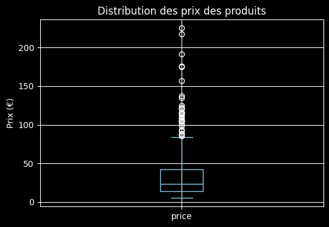

```python
#Création d'une boîte à moustache de la répartition des prix grâce à Pandas
df_final["price"].plot(kind="box", figsize=(6,4), grid=True, color="skyblue")
plt.title("Distribution des prix des produits")
plt.ylabel("Prix (€)")
plt.show()
```

```python
#Autre méthode avec plotly express

fig = px.box(df_final, y="price", points="all", color_discrete_sequence=["#1f77b4"])
fig.update_layout(
    title="Distribution interactive des prix des produits",
    yaxis_title="Prix (€)",
    template="plotly_dark"
)
fig.show()
```

📊 **Exploration de la répartition des prix**

Une première analyse visuelle a été réalisée à l’aide d’une **boîte à moustaches** afin de visualiser la distribution des prix dans le catalogue.

Cette représentation met en évidence plusieurs éléments :

- 📦 La majorité des produits sont concentrés dans une fourchette de prix comprise entre **environ 10 € et 45 €**.
- 💡 De nombreux points situés au-dessus de la boîte indiquent la présence de **valeurs atypiques** (produits beaucoup plus chers que la moyenne).
- 📉 La distribution est **asymétrique vers la droite** : peu de produits très chers tirent la moyenne vers le haut.

Ce premier constat suggère que le dataset contient plusieurs **produits haut de gamme** ou à prix élevés, qui pourraient être considérés comme des **valeurs extrêmes**. Une analyse statistique plus précise (IQR) permettra ensuite de les identifier formellement.

### Etape 4.2 - Exploration par l'utilisation de méthodes statistiques

```python
# Statistiques descriptives
stats_price = df_final["price"].describe()
variance = df_final["price"].var()
ecart_type = df_final["price"].std()
skewness = df_final["price"].skew()  # asymétrie

print("📈 Statistiques descriptives des prix :")
display(stats_price)
print(f"⚙️ Variance : {variance:.2f}")
print(f"📊 Écart-type : {ecart_type:.2f}")
print(f"🔁 Coefficient d’asymétrie (skewness) : {skewness:.2f}")
```

```
📈 Statistiques descriptives des prix :
```

```
count    714.000000
mean      32.333683
std       27.596332
min        5.200000
25%       14.062500
50%       23.450000
75%       42.075000
max      225.000000
Name: price, dtype: float64
```

```
⚙️ Variance : 761.56
📊 Écart-type : 27.60
🔁 Coefficient d’asymétrie (skewness) : 2.60
```

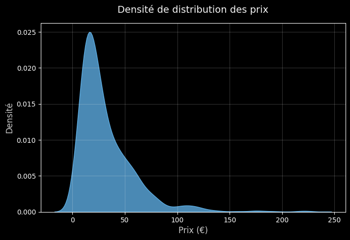

```python
# Graphique de densité
plt.style.use("dark_background")

plt.figure(figsize=(8,5))
sns.kdeplot(df_final["price"], fill=True, color="#5dade2", alpha=0.8)
plt.title("Densité de distribution des prix", fontsize=14, color="#f5f5f5", pad=15)
plt.xlabel("Prix (€)", fontsize=12, color="#cccccc")
plt.ylabel("Densité", fontsize=12, color="#cccccc")
plt.grid(alpha=0.2)
plt.show()
```

📊 **Exploration statistique des prix**

Cette étape vise à **analyser la répartition des prix** dans le catalogue avant d’appliquer des méthodes de détection des valeurs extrêmes.

💡 En résumé, le graphique montre une **concentration forte sur des prix abordables** et une **traîne étendue vers les produits haut de gamme**. Cette répartition justifie l’utilisation, dans les étapes suivantes, de méthodes robustes pour identifier les valeurs atypiques (Z-score et IQR).

### Etape 4.2.1 - Identification par le Z-index

```python
# Calculer la moyenne du prix
mean_price = df_final["price"].mean()
print(f"📊 Moyenne du prix : {mean_price:.2f}")

# Calculer l'écart-type du prix
std_price = df_final["price"].std()
print(f"⚙️ Écart-type du prix : {std_price:.2f}")

# Calculer le Z-score
df_final["z_score"] = (df_final["price"] - mean_price) / std_price

# Afficher les premières valeurs
display(df_final[["product_id", "price", "z_score"]].head())
```

```
📊 Moyenne du prix : 32.33
⚙️ Écart-type du prix : 27.60
```

|  | product_id | price | z_score |
| --- | --- | --- | --- |
| 0 | 3847 | 24.2 | -0.294738 |
| 1 | 3849 | 34.3 | 0.071253 |
| 2 | 3850 | 20.8 | -0.417943 |
| 3 | 4032 | 14.1 | -0.660729 |
| 4 | 4039 | 46.0 | 0.495222 |

```python
# Quel est le seuil de prix dont le Z-score est supérieur à 3 ?
outliers_z = df_final[df_final["z_score"] > 3]

print(f"🚨 Nombre de produits avec un Z-score > 3 : {len(outliers_z)}")
display(outliers_z[["product_id", "price", "z_score"]].head())

# Seuil de prix correspondant
if not outliers_z.empty:
    seuil_prix = outliers_z["price"].min()
    print(f"💰 Seuil de prix à partir duquel le Z-score dépasse 3 : {seuil_prix:.2f}")
else:
    print("✅ Aucun prix avec un Z-score supérieur à 3.")
```

```
🚨 Nombre de produits avec un Z-score > 3 : 13
```

|  | product_id | price | z_score |
| --- | --- | --- | --- |
| 200 | 4352 | 225.0 | 6.981591 |
| 219 | 4402 | 176.0 | 5.205993 |
| 222 | 4406 | 157.0 | 4.517496 |
| 387 | 4904 | 137.0 | 3.792762 |
| 434 | 5001 | 217.5 | 6.709816 |

```
💰 Seuil de prix à partir duquel le Z-score dépasse 3 : 116.40
```

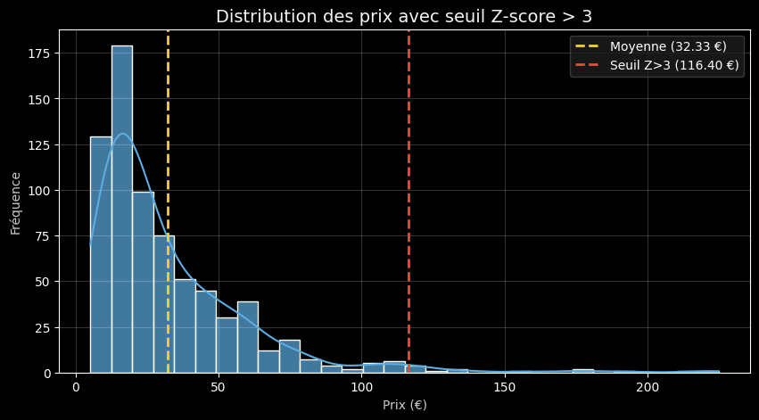

```python
# Graphique Z-Index

plt.style.use("dark_background")

plt.figure(figsize=(10, 5))
sns.histplot(df_final["price"], bins=30, kde=True, color="#5dade2", alpha=0.7)
plt.axvline(mean_price, color="#f4d03f", linestyle="--", linewidth=2, label=f"Moyenne ({mean_price:.2f} €)")
if seuil_prix:
    plt.axvline(seuil_prix, color="#e74c3c", linestyle="--", linewidth=2, label=f"Seuil Z>3 ({seuil_prix:.2f} €)")

plt.title("Distribution des prix avec seuil Z-score > 3", fontsize=14, color="#f5f5f5")
plt.xlabel("Prix (€)", color="#cccccc")
plt.ylabel("Fréquence", color="#cccccc")
plt.legend(facecolor="#1e1e1e", edgecolor="#444", fontsize=10)
plt.grid(alpha=0.2)
plt.show()
```

📈 **Analyse par le Z-score**

Le **Z-score** (ou indice de position normalisée) mesure **à combien d’écarts-types** une valeur se situe par rapport à la moyenne. C’est une méthode classique pour **identifier les valeurs extrêmes** dans une distribution de données.

Dans notre cas, les produits dont le Z-score dépasse 3 sont considérés comme des **outliers**, c’est-à-dire des prix anormalement élevés par rapport au reste du catalogue.

💡 Cette méthode est particulièrement utile pour les données **suivant une distribution normale**, car elle permet de repérer objectivement les écarts importants à la moyenne.

Les produits au-delà de ce seuil sont probablement des **articles premium** ou des **valeurs exceptionnelles** nécessitant une vérification manuelle.

### Etape 4.2.2 - Identification par l'intervalle interquartile

```python
#Utilisation de la fonction "describe" de Pandas pour l'étude des mesures de dispersion
stats_price = df_final["price"].describe()
display(stats_price)

prix_max = df_final["price"].max()
produits_plus_chers = df_final[df_final["price"] == prix_max].copy()

cols = ["product_id", "id_web", "sku", "post_title", "price", "purchase_price", "stock_quantity", "stock_status", "total_sales"]
cols = [c for c in cols if c in produits_plus_chers.columns]

display(produits_plus_chers[cols].reset_index(drop=True))
```

```
count    714.000000
mean      32.333683
std       27.596332
min        5.200000
25%       14.062500
50%       23.450000
75%       42.075000
max      225.000000
Name: price, dtype: float64
```

|  | product_id | id_web | sku | post_title | price | purchase_price | stock_quantity | stock_status | total_sales |
| --- | --- | --- | --- | --- | --- | --- | --- | --- | --- |
| 0 | 4352 | 15940 | 15940 | Champagne Egly-Ouriet Grand Cru Millésimé 2008 | 225.0 | 137.81 | 0 | outofstock | 11.0 |

```python
#Définir un seuil pour les articles "outliers" en prix
# Calcul des quartiles et de l’IQR (Intervalle InterQuartile)
Q1 = df_final["price"].quantile(0.25)
Q3 = df_final["price"].quantile(0.75)
IQR = Q3 - Q1

# Définition des bornes
borne_inf = Q1 - 1.5 * IQR
borne_sup = Q3 + 1.5 * IQR

print(f"📈 IQR : {IQR:.2f}")
print(f"🔹 Borne inférieure : {borne_inf:.2f}")
print(f"🔹 Borne supérieure : {borne_sup:.2f}")
```

```
📈 IQR : 28.01
🔹 Borne inférieure : -27.96
🔹 Borne supérieure : 84.09
```

```python
#Définir le nombre d'articles et la proportion de l'ensemble du catalogue "outliers"
# Détection des valeurs extrêmes selon l'IQR
outliers_iqr = df_final[(df_final["price"] < borne_inf) | (df_final["price"] > borne_sup)]

# Calcul du pourcentage d’outliers
pourcentage = (len(outliers_iqr) / len(df_final)) * 100

print(f"🌸 Nombre d’articles considérés comme outliers : {len(outliers_iqr)}")
print(f"📊 Cela représente {pourcentage:.2f}% du catalogue.")
display(outliers_iqr[["product_id", "price"]].head())
```

```
🌸 Nombre d’articles considérés comme outliers : 31
📊 Cela représente 4.34% du catalogue.
```

|  | product_id | price |
| --- | --- | --- |
| 63 | 4115 | 100.0 |
| 65 | 4132 | 88.4 |
| 200 | 4352 | 225.0 |
| 206 | 4359 | 85.6 |
| 219 | 4402 | 176.0 |

```python
#Selon vous, ces outliers sont-ils justifiés ? Comment le démontrer si cela est possible ?
df_final["rating_count"] = df_final["rating_count"].fillna(0)
df_final["total_sales"] = df_final["total_sales"].fillna(0)
df_final["average_rating"] = df_final["average_rating"].fillna(0)

# Identifier les outliers
ventes_outliers = df_final[df_final["product_id"].isin(outliers_iqr["product_id"])]
ventes_non_outliers = df_final[~df_final["product_id"].isin(outliers_iqr["product_id"])]

print(f"Outliers (prix > borne_sup) : {len(ventes_outliers)} articles")
print(f"Non-outliers : {len(ventes_non_outliers)} articles")
```

```
Outliers (prix > borne_sup) : 31 articles
Non-outliers : 683 articles
```

```python
# Graphique avec les deux ensembles
fig = px.scatter(
    ventes_non_outliers,
    x="price",
    y="total_sales",
    color_discrete_sequence=["skyblue"],
    opacity=0.6,
    labels={"price": "Prix (€)", "total_sales": "Ventes totales"},
    title="Ventes normales (bleu) vs valeurs extrêmes (rouge)",
    template="plotly_dark"
)

# Ajouter les outliers de prix en rouge
fig.add_scatter(
    x=ventes_outliers["price"],
    y=ventes_outliers["total_sales"],
    mode="markers",
    marker=dict(size=10, color="red", symbol="circle"),
    name="Outliers (prix élevés)"
)

fig.update_layout(showlegend=True)
fig.show()
```

📊 **Analyse des valeurs extrêmes selon l’intervalle interquartile (IQR)**

L’**IQR (InterQuartile Range)** permet d’identifier les valeurs extrêmes en se basant sur la **dispersion centrale des données** plutôt que sur la moyenne. Cette méthode est particulièrement robuste, car elle **n’est pas influencée par les valeurs aberrantes**.

Dans notre dataset, les bornes calculées montrent que tout prix supérieur à **≈ 84 €** peut être considéré comme une valeur extrême. Cela représente environ **4,34 %** du catalogue, soit **31 articles**.

💡 Cette méthode est idéale pour repérer les produits au comportement atypique sans que la moyenne (souvent biaisée par quelques valeurs très hautes) ne perturbe l’analyse.

📈 **Analyse des valeurs extrêmes par les ventes**

Le nuage de points comparant le **prix** et les **ventes totales** met en évidence les produits à prix élevés (en rouge) se détachant du reste du catalogue.

- 🔴 Ces articles correspondent à des **prix supérieurs à 84 €**.
- 📦 Ils présentent des **ventes variées**, ce qui montre qu’un prix élevé n’implique pas nécessairement un faible volume de ventes.
- 💬 Ces valeurs extrêmes sont donc **justifiées commercialement** : il s’agit probablement de **produits premium** ou bénéficiant d’une **forte visibilité**.

✅ **Conclusion :** les outliers identifiés par l’IQR ne traduisent pas une anomalie de données, mais bien la présence de **produits haut de gamme cohérents** avec la structure du catalogue.

## Etape 5 - Analyse univariée du CA, des quantités vendues, des stocks et de la marge ainsi qu'une analyse multivariée

### Etape 5.1 - Analyse des ventes en CA

```python
##############################
# Calculer le CA du site web #
##############################
print(df_final["total_sales"].describe())
print(df_final["total_sales"].value_counts().head(10))


#Créer une colonne calculant le CA par article
df_final["ca_par_article"] = df_final["price"] * df_final["total_sales"]

#Calculer la somme de la colonne "ca_par_article"
#Ce résultat correspond au chiffre d'affaire du site web
ca_total = df_final["ca_par_article"].sum()

print(f"💰 Chiffre d'affaires total du site web : {ca_total:,.2f} €")
```

```
count    714.000000
mean       8.054622
std        4.161344
min        0.000000
25%        5.000000
50%        8.000000
75%       11.000000
max       36.000000
Name: total_sales, dtype: float64
total_sales
9.0     70
7.0     70
10.0    65
8.0     60
6.0     57
5.0     54
11.0    51
12.0    49
4.0     47
13.0    43
Name: count, dtype: int64
💰 Chiffre d'affaires total du site web : 143,680.10 €
```

```python
###############################
# Palmarès des articles en CA #
###############################

#Effectuer le tri dans l'ordre décroissant du CA du dataset df_merge
palmares = df_final.sort_values(by="ca_par_article", ascending=False).reset_index(drop=True)

#Réinitialiser l'index du dataset par un reset_index

#Afficher les 20 premiers articles en CA

#Graphique en barre des 20 premiers articles avec plotly express

fig = px.bar(
    palmares.head(20),
    x="post_title",
    y="ca_par_article",
    title="🏆 Top 20 des articles en chiffre d'affaires",
    labels={"post_title": "Article", "ca_par_article": "Chiffre d'affaires (€)"},
)
fig.update_layout(xaxis_tickangle=-45, plot_bgcolor="#111", paper_bgcolor="#111", font_color="white")
fig.show()
```

```python
# Calcul de la part du CA par ligne
df_final["part_ca"] = df_final["ca_par_article"] / ca_total

# Calcul de la somme cumulative
df_final["cumul_ca"] = df_final["part_ca"].cumsum()

# Trouver le nombre d’articles représentant 80% du CA
nb_articles_80 = df_final[df_final["cumul_ca"] <= 0.8].shape[0]

# Proportion de ces articles dans le catalogue
proportion = (nb_articles_80 / len(df_final)) * 100

print(f"📊 Nombre d'articles représentant 80% du CA : {nb_articles_80}")
print(f"⚙️ Ils représentent {proportion:.2f}% du catalogue total.")
```

```
📊 Nombre d'articles représentant 80% du CA : 590
⚙️ Ils représentent 82.63% du catalogue total.
```

📊 **Analyse du chiffre d'affaires global**

💰 Le chiffre d’affaires total du site web s’élève à **143 680,10 €**.

### Etape 5.2 - Analyse des ventes en quantité

```python
#####################################
# Palmarès des articles en quantité #
#####################################

# Trier les articles selon la quantité totale vendue (ordre décroissant)
palmares_qte = df_final.sort_values(by="total_sales", ascending=False).reset_index(drop=True)

# Afficher les 20 premiers articles les plus vendus
fig = px.bar(
    palmares_qte.head(20),
    x="post_title",
    y="total_sales",
    title="🏆 Top 20 des articles les plus vendus (en quantités)",
    labels={"post_title": "Article", "total_sales": "Quantité vendue"},
)
fig.update_layout(xaxis_tickangle=-45, plot_bgcolor="#111", paper_bgcolor="#111", font_color="white")
fig.show()
```

```python
#############################
# Calculer le 20 / 80 en CA #
#############################

# Calcul de la part de chaque article dans les ventes totales
df_final["part_qte"] = df_final["total_sales"] / df_final["total_sales"].sum()

# Calcul de la somme cumulative
df_final["cumul_qte"] = df_final["part_qte"].cumsum()

# Trouver le nombre d’articles représentant 80 % des ventes totales
nb_articles_80_qte = df_final[df_final["cumul_qte"] <= 0.8].shape[0]

# Proportion dans le catalogue
proportion_qte = (nb_articles_80_qte / len(df_final)) * 100

print(f"📦 Nombre d'articles représentant 80 % des ventes : {nb_articles_80_qte}")
print(f"⚙️ Cela représente {proportion_qte:.2f}% du catalogue total.")
```

```
📦 Nombre d'articles représentant 80 % des ventes : 560
⚙️ Cela représente 78.43% du catalogue total.
```

📦 **Analyse des ventes en quantité**

🍷 Les articles les plus vendus en volume sont principalement des **vins accessibles** et des **champagnes populaires**, témoignant d’un attrait fort pour les produits de consommation courante.

📈 **560 articles** représentent **80 %** des ventes totales, soit environ **78,4 %** du catalogue global.

⚙️ Ces résultats permettent d’identifier les **produits stratégiques** à maintenir en stock en priorité et ceux à cibler dans les **campagnes promotionnelles**.

### Etape 5.3 - Analyse des stocks

```python
######################################
# Calculer le nombre de mois de stock #
######################################


# Création d'une colonne "rotation_stock" : rapport entre stock et ventes
# (évite les divisions par zéro)
df_final["rotation_stock"] = np.where(df_final["total_sales"] > 0,
                                      df_final["stock_quantity"] / df_final["total_sales"],
                                      np.nan)

# Remplacer les infinis et valeurs nulles
df_final["rotation_stock"] = df_final["rotation_stock"].replace([np.inf, -np.inf], np.nan)
df_final["rotation_stock"] = df_final["rotation_stock"].fillna(0)

# Trier par rotation décroissante (les produits qui restent le plus longtemps en stock)
flop20_stock = df_final.sort_values(by="rotation_stock", ascending=False).head(20)

# Graphique du flop 20 (les 20 produits les plus lents à s’écouler)
fig = px.bar(
    flop20_stock,
    x="post_title",
    y="rotation_stock",
    title="🐢 Flop 20 des produits avec le plus de mois de stock (rotation lente)",
    labels={"post_title": "Article", "rotation_stock": "Mois de stock estimés"},
)
fig.update_layout(xaxis_tickangle=-45, plot_bgcolor="#111", paper_bgcolor="#111", font_color="white")
fig.show()
```

```python
####################################
# Valorisation des stocks en euros #
####################################

# Création de la colonne de valorisation du stock
df_final["valorisation_stock_euros"] = df_final["stock_quantity"] * df_final["purchase_price"]

# Calcul de la valorisation totale
val_stock_total = df_final["valorisation_stock_euros"].sum()
print(f"💶 Valeur totale du stock : {val_stock_total:,.2f} €")
```

```
💶 Valeur totale du stock : 277,328.07 €
```

```python
##############################################
# Valorisation du nombre de produits en stock #
##############################################

#Calculer la somme de la colonne stock quantity
nb_produits_stock = df_final["stock_quantity"].sum()
print(f"📦 Nombre total de produits en stock : {nb_produits_stock:,.0f}")
```

```
📦 Nombre total de produits en stock : 16,740
```

📦 **Analyse des stocks**

🐢 Le **flop 20** des produits à rotation lente regroupe principalement des **champagnes haut de gamme** dont les ventes restent faibles par rapport aux quantités disponibles, suggérant un **stock à faible rotation**.

💶 La **valorisation totale du stock** est estimée à **277 328,07 €**, pour un total de **16 740 unités** en entrepôt.  
Ce volume est significatif par rapport au chiffre d’affaires global (**143 680,10 €**), indiquant un **niveau d’immobilisation financière élevé**.

💡 Cette situation met en évidence un **surstock potentiel** sur certaines références premium, nécessitant une stratégie d’écoulement ciblée : **promotions, ventes croisées ou ajustement du catalogue**.

### Etape 5.4 - Analyse du taux de marge

```python
############################
# Analyse du taux de marge #
############################

# Création de la colonne "Prix HT" (prix sans TVA)
df_final["prix_ht"] = df_final["price"] / 1.20  # suppose TVA à 20%

# Création de la colonne "Taux de marge commerciale"
df_final["taux_marge"] = ((df_final["prix_ht"] - df_final["purchase_price"]) / df_final["prix_ht"]) * 100

# Nettoyage des valeurs infinies et NaN
df_final["taux_marge"] = df_final["taux_marge"].replace([np.inf, -np.inf], np.nan)

# Affichage des statistiques
print("📊 Statistiques du taux de marge :")
display(df_final["taux_marge"].describe())
```

```
📊 Statistiques du taux de marge :
```

```
count    714.000000
mean      36.880155
std       25.372612
min     -634.988142
25%       36.134325
50%       37.992126
75%       39.865331
max       47.756800
Name: taux_marge, dtype: float64
```

```python
# ------------------------------
# Affichage de la ligne avec un taux de marge inférieur à 0
# ------------------------------
# Produits à marge négative
marges_neg = df_final[df_final["taux_marge"] < 0]
print(f"🚨 Nombre de produits à marge négative : {len(marges_neg)}")

cols = ["product_id","purchase_price","price","taux_marge","stock_quantity","stock_status","sku","post_title"]
cols = [c for c in cols if c in marges_neg.columns]

display(
    marges_neg[cols]
    .sort_values("taux_marge")
    .reset_index(drop=True)
)
```

```
🚨 Nombre de produits à marge négative : 1
```

|  | product_id | purchase_price | price | taux_marge | stock_quantity | stock_status | sku | post_title |
| --- | --- | --- | --- | --- | --- | --- | --- | --- |
| 0 | 4355 | 77.48 | 12.65 | -634.988142 | 97 | instock | 12589 | Champagne Egly-Ouriet Grand Cru Blanc de Noirs |

```python
# ------------------------------
# Filtrer les taux de marge positifs
# ------------------------------
df_marges_pos = df_final[df_final["taux_marge"] > 0]

# Affichage du minimum et maximum des marges positives
min_marge = df_marges_pos["taux_marge"].min()
max_marge = df_marges_pos["taux_marge"].max()

print(f"📉 Taux de marge minimum (positif) : {min_marge:.2f} %")
print(f"📈 Taux de marge maximum : {max_marge:.2f} %")
```

```
📉 Taux de marge minimum (positif) : 22.78 %
📈 Taux de marge maximum : 47.76 %
```

```python
# ------------------------------
# Moyenne du taux de marge par type de produit
# ------------------------------
marge_par_type = df_marges_pos.groupby("product_type")["taux_marge"].mean().reset_index()

# Tri pour affichage propre
marge_par_type = marge_par_type.sort_values(by="taux_marge", ascending=False)

# Graphique
fig = px.bar(
    marge_par_type,
    x="product_type",
    y="taux_marge",
    title="📊 Taux de marge moyen par type de produit",
    labels={"product_type": "Type de produit", "taux_marge": "Taux de marge moyen (%)"},
)
fig.update_layout(plot_bgcolor="#111", paper_bgcolor="#111", font_color="white")
fig.show()
```

📊 **Analyse du taux de marge**

💶 Le taux de marge moyen observé sur le catalogue est de **36,9 %**, avec des valeurs positives comprises entre **22,78 %** et **47,76 %**.

⚠️ **1 produit présente une marge négative (≈ –635 %)**, ce qui est **économiquement incohérent** et suggère une **erreur de saisie.**

📈 Les produits les plus rentables sont principalement les **Cognacs** et les **Whiskys**, avec un taux de marge moyen supérieur à 40 %, tandis que les **Champagnes** et les **Huiles d’olive** affichent des marges plus modestes (entre 25 et 30 %).

💡 Cette analyse permet d’identifier les gammes les plus rentables et de repérer celles nécessitant une **révision tarifaire** ou une **optimisation stratégique**.

### Etape 5.5 - Analyse des corrélations entre les variables stock, sales et price

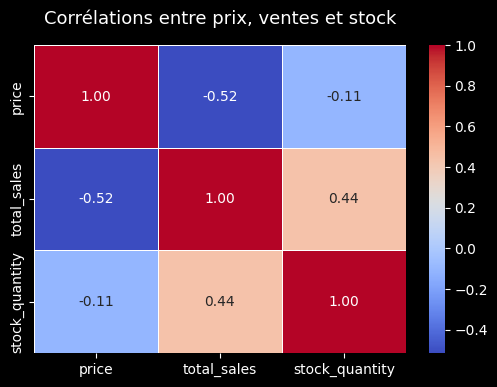

```
📊 Matrice de corrélation :
```

|  | price | total_sales | stock_quantity |
| --- | --- | --- | --- |
| price | 1.000000 | -0.516258 | -0.106654 |
| total_sales | -0.516258 | 1.000000 | 0.438930 |
| stock_quantity | -0.106654 | 0.438930 | 1.000000 |

```python
############################
# Analyse des corrélations #
############################

# Sélection des variables pertinentes
variables_corr = df_final[["price", "total_sales", "stock_quantity"]]

# Calcul de la matrice de corrélation
corr_matrix = variables_corr.corr()

# Affichage de la heatmap
plt.figure(figsize=(6,4))
sns.heatmap(corr_matrix, annot=True, cmap="coolwarm", fmt=".2f", linewidths=0.5)
plt.title("Corrélations entre prix, ventes et stock", fontsize=13, color="white", pad=15)
plt.show()

# Affichage de la matrice brute
print("📊 Matrice de corrélation :")
display(corr_matrix)
```

📊 **Analyse des corrélations**

🔹 Une corrélation **négative modérée** (-0,52) existe entre le **prix** et les **ventes** : plus le prix augmente, plus les ventes ont tendance à diminuer — un effet logique de sensibilité au prix.

🔹 La corrélation entre **prix** et **stock** est **faiblement négative** (-0,11), ce qui suggère que les produits plus chers sont légèrement moins présents en stock, sans relation forte.

🔹 Une corrélation **positive modérée** (0,44) est observée entre **ventes** et **stock** : les produits les plus vendus disposent souvent de stocks plus importants, probablement en raison d’un réassort plus fréquent.

💡 En résumé, les ventes sont davantage influencées par le **niveau de prix** et la **gestion des stocks** que par d’autres variables, confirmant une logique économique classique : une demande plus forte entraîne des volumes et des stocks plus élevés.

### Etape 5.6 - Mise à disposition de la nouvelle table sur un fichier Excel

```python
#Mettre le dataset df_merge sur un fichier Excel

from pathlib import Path

# Créer le dossier outputs s'il n'existe pas
# Path("outputs").mkdir(parents=True, exist_ok=True)

# Export Excel dans outputs/
# output_path = Path("outputs") / "df_final_analyse.xlsx"
# df_final.to_excel(output_path, index=False)

# print(f"✅ Export réussi : {output_path}")
```

[output not shown]